# U1-Predicting-response-times-of-the-Paris-Fire_Brigade-vehicles

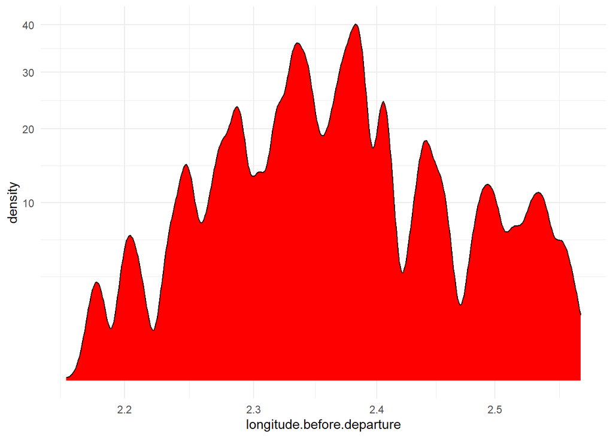

```r
data.quanti %>%
  ggplot(aes(longitude.before.departure)) +
  geom_density(fill = "red", bins = 100) +
  scale_x_log10() +
  scale_y_sqrt() +
  theme_minimal()
```

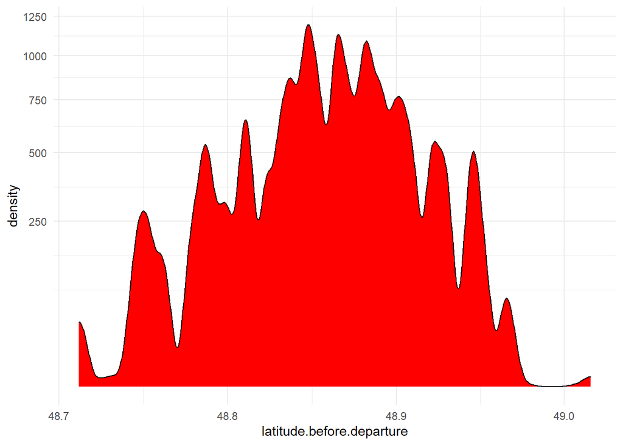

```r
data.quanti %>%
  ggplot(aes(latitude.before.departure)) +
  geom_density(fill = "red", bins = 100) +
  scale_x_log10() +
  scale_y_sqrt() +
  theme_minimal()
```

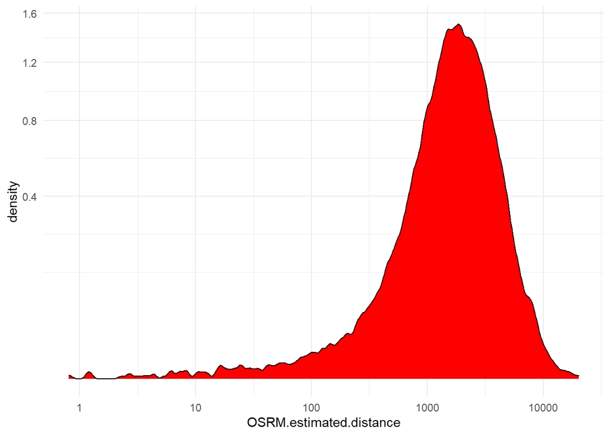

```r
data.quanti %>%
  ggplot(aes(OSRM.estimated.distance)) +
  geom_density(fill = "red", bins = 100) +
  scale_x_log10() +
  scale_y_sqrt() +
  theme_minimal()
```

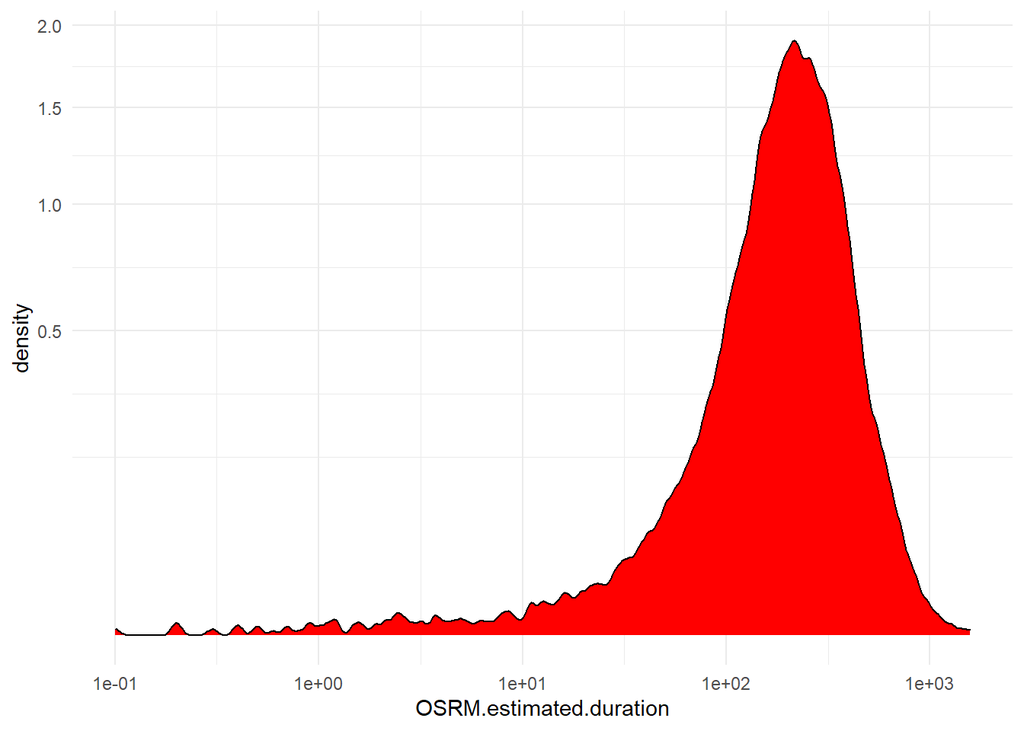

```r
data.quanti %>%
  ggplot(aes(OSRM.estimated.duration)) +
  geom_density(fill = "red", bins = 100) +
  scale_x_log10() +
  scale_y_sqrt() +
  theme_minimal()
```

##### 3.1.1.3 Boxplots

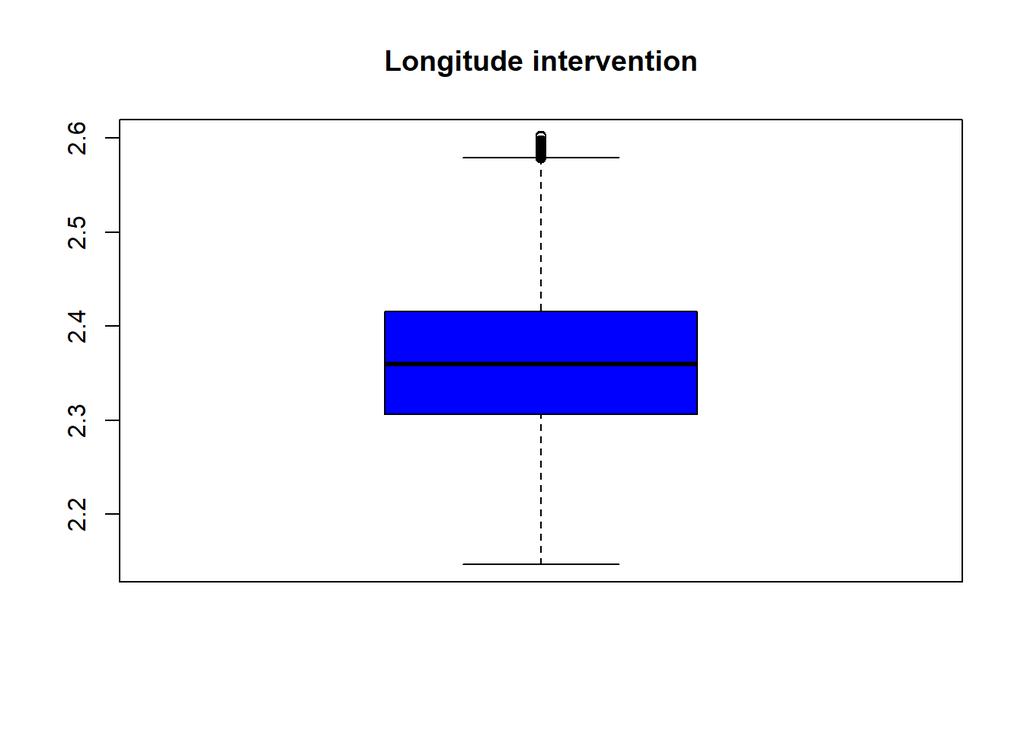

```r
boxplot(data.quanti$longitude.intervention, col="blue",main="Longitude intervention")
```

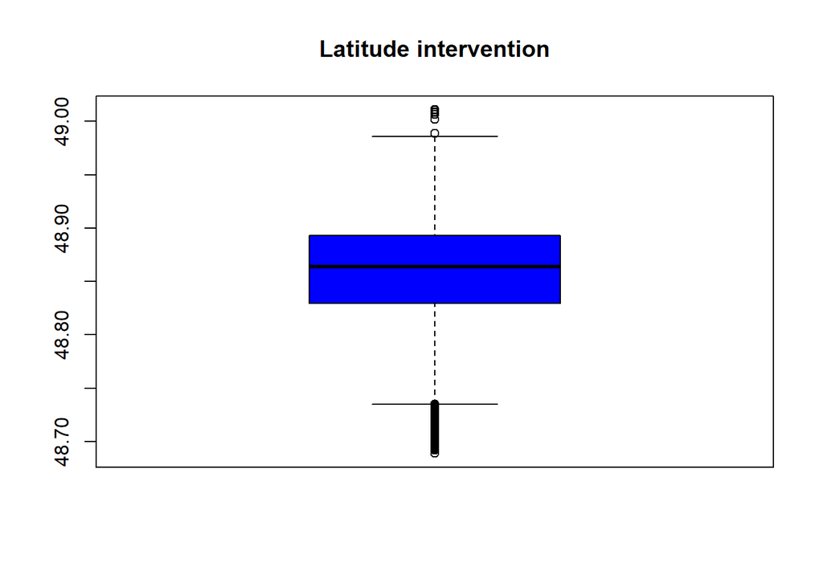

```r
boxplot(data.quanti$latitude.intervention, col="blue",main="Latitude intervention")
```

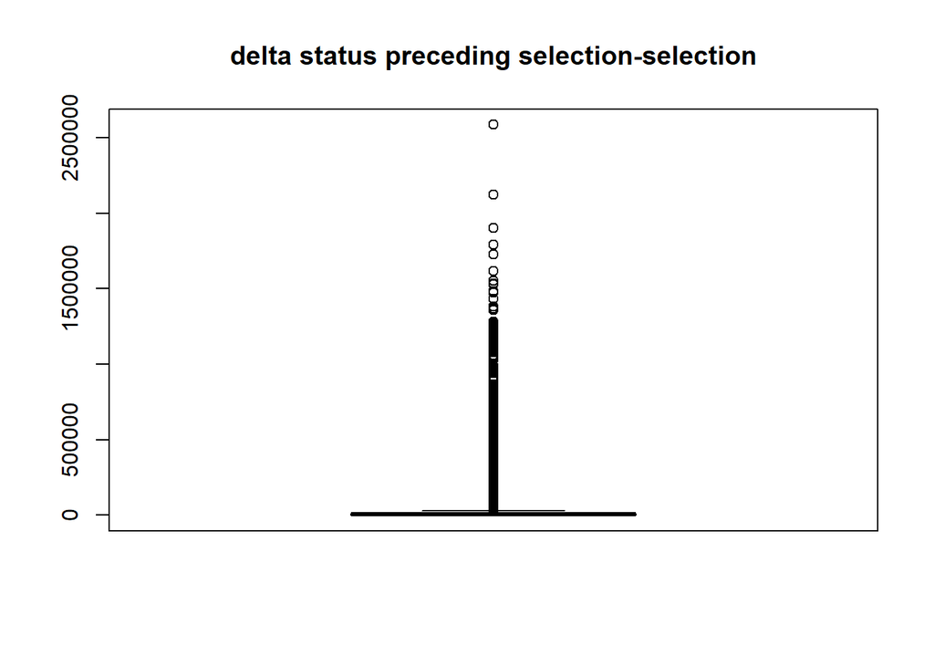

```r
boxplot(data.quanti$delta.status.preceding.selection.selection , col="blue",main="delta status preceding selection-selection")
```

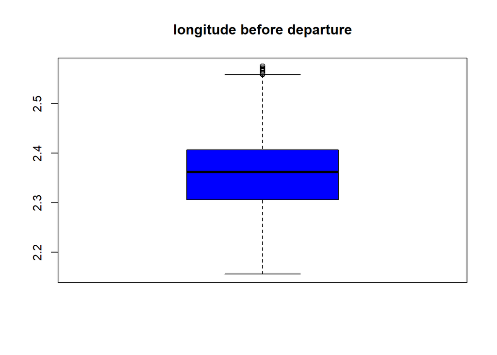

```r
boxplot(data.quanti$longitude.before.departure, col="blue",main="longitude before departure")
```

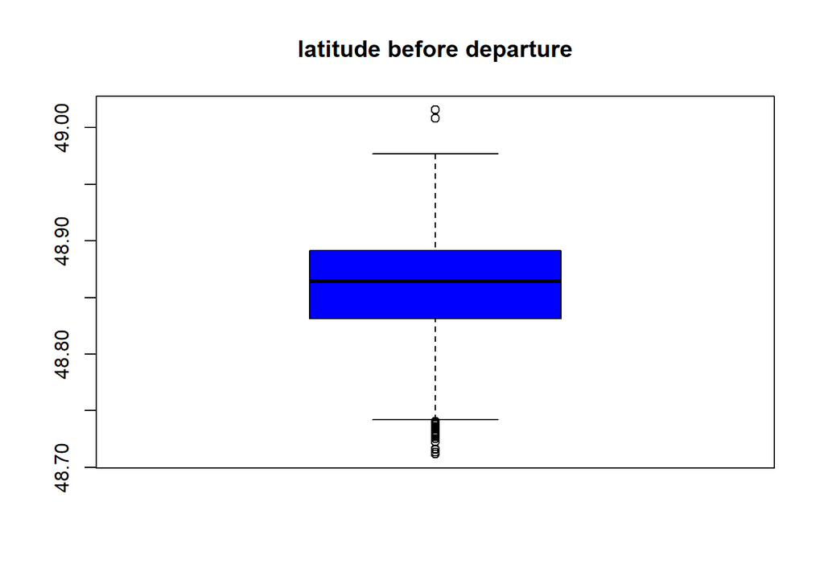

```r
boxplot(data.quanti$latitude.before.departure, col="blue",main="latitude before departure")
```

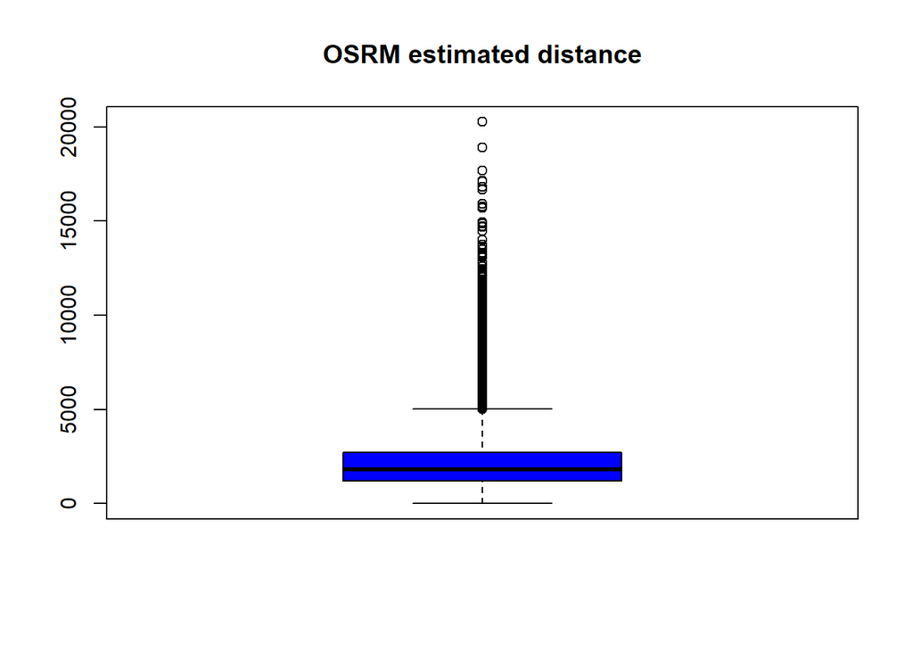

```r
boxplot(data.quanti$OSRM.estimated.distance, col="blue",main="OSRM estimated distance")
```

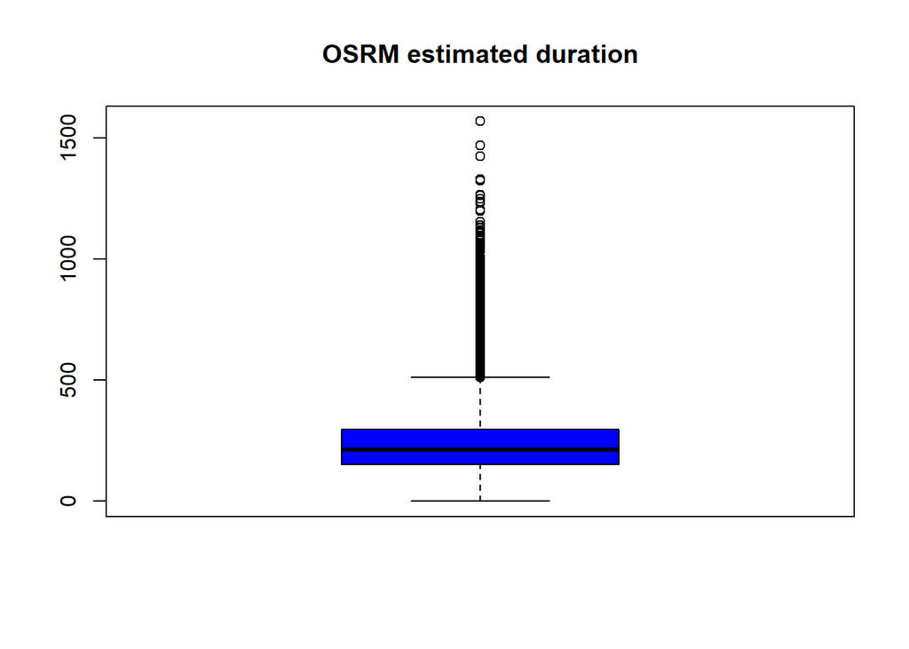

```r
boxplot(data.quanti$OSRM.estimated.duration, col="blue",main="OSRM estimated duration")
```

##### 3.1.1.3 Manage Outliers

```r
data.clean <- data[data$delta.status.preceding.selection.selection < 100000,]
data.clean <- data[data$OSRM.estimated.duration < 1000,]


#Assign the new value to data.quanti
colnames(data.clean)
```

```
##  [1] "emergency.vehicle.selection"
##  [2] "intervention"
##  [3] "alert.reason.category"
##  [4] "alert.reason"
##  [5] "intervention.on.public.roads"
##  [6] "floor"
##  [7] "location.of.the.event"
##  [8] "longitude.intervention"
##  [9] "latitude.intervention"
## [10] "emergency.vehicle"
## [11] "emergency.vehicle.type"
## [12] "rescue.center"
## [13] "date.key.selection"
## [14] "time.key.selection"
## [15] "status.preceding.selection"
## [16] "delta.status.preceding.selection.selection"
## [17] "departed.from.its.rescue.center"
## [18] "longitude.before.departure"
## [19] "latitude.before.departure"
## [20] "GPS.tracks.departure.presentation"
## [21] "GPS.tracks.datetime.departure.presentation"
## [22] "OSRM.estimated.distance"
## [23] "OSRM.estimated.duration"
## [24] "delta.selection.departure"
## [25] "delta.departure.presentation"
## [26] "delta.selection.presentation"
```

```r
data.quanti<-data.clean[,-c(3,4,5,6,7,10,11,12,15,17,24,25,26)]
data.quanti.y<-data.clean[,-c(3,4,5,6,7,10,11,12,15,17)]
```

#### 3.1.2 Qualitative Variables

##### 3.1.2.1 Tables

```r
str(data.quali)
```

```
## Classes 'data.table' and 'data.frame':   206625 obs. of  10 variables:
##  $ alert.reason.category          : Factor w/ 9 levels "1","2","3","4",..: 3 3 3 3 3 3 9 3 3 3 ...
##  $ alert.reason                   : Factor w/ 122 levels "1911","1912",..: 60 41 61 60 60 31 101 60 32 31 ...
##  $ intervention.on.public.roads   : Factor w/ 2 levels "0","1": 1 1 1 1 1 1 1 1 2 1 ...
##  $ floor                          : Factor w/ 45 levels "-10","-6","-5",..: 8 9 10 8 11 9 12 8 8 8 ...
##  $ location.of.the.event          : Factor w/ 210 levels "100","101","102",..: 48 36 39 36 5 56 36 36 48 94 ...
##  $ emergency.vehicle              : Factor w/ 639 levels "1815","1823",..: 398 334 396 517 473 330 293 575 398 606 ...
##  $ emergency.vehicle.type         : Factor w/ 41 levels "AR","BEAA BSPP",..: 37 24 37 37 37 37 24 37 37 37 ...
##  $ rescue.center                  : Factor w/ 79 levels "2418","2434",..: 15 30 6 72 42 55 42 16 15 50 ...
##  $ status.preceding.selection     : Factor w/ 2 levels "Disponible","RentrÃ©": 2 2 1 2 2 2 2 2 2 2 ...
##  $ departed.from.its.rescue.center: Factor w/ 2 levels "0","1": 2 2 1 2 2 2 2 2 2 2 ...
##  - attr(*, ".internal.selfref")=<externalptr>
```

```r
table(data.quali$alert.reason.category)
```

```
##
##      1      2      3      4      5      6      7      8      9
##  15032   5401 172293   1185    614   4019    715    188   7178
```

```r
prop.table(table(data.quali$alert.reason.category))
```

```
##
##            1            2            3            4            5            6
## 0.0727501512 0.0261391410 0.8338439201 0.0057350272 0.0029715668 0.0194506957
##            7            8            9
## 0.0034603751 0.0009098609 0.0347392619
```

```r
table(data.quali$alert.reason)
```

```
##
##  1911  1912  1914  1918  1920  1922  1923  1924  1926  1927  1929  1932  1934
##   111   699   977  1305     3  8426   261   264     5    24   575     3     2
##  1940  1941  1942  1944  1951  1952  2011  2012  2014  2015  2017  2018  2020
##   433  1911     6     2    23     2  1914    22     3    21  1490  1933     4
##  2021  2022  2026  2028  2112  2113  2115  2116  2118  2119  2120  2121  2122
##     3     3     5     3 36679 22790    82   511  1722  2164  3327    62    11
##  2123  2124  2126  2127  2128  2129  2131  2132  2133  2134  2135  2136  2137
##    17  5693   184     1     1    73    33   791     6  3362  7498  1661    43
##  2141  2142  2143  2144  2145  2146  2147  2162  2163  2210  2211  2212  2213
##   457    18   341    10     1     8    66 66310 15052     4    28   556    17
##  2214  2215  2216  2218  2221  2311  2312  2313  2314  2317  2411  2412  2413
##   358     3   212     1     9   162   143   229    79     1   163    93     1
##  2414  2416  2421  2422  2423  2424  2426  2430  2431  2432  2511  2514  2519
##     3     6  2350   164    28    19   621     2   240    45    21    30     1
##  2523  2524  2525  2532  2612  2613  2614  2623  2624  2711  2712  2714  2715
##    79   467    55    62     1     2    10   165    10  5744    13     5     2
##  2716  2720  2724  2725  2727  2752  2753  4926  5061  5062  5811  7912  7913
##  1185    84    16    18     1    56    10    12   369  2934     1    57   162
##  7914 10821 10971 11021 93529
##    65     1     1     5    37
```

```r
prop.table(table(data.quali$alert.reason))
```

```
##
##         1911         1912         1914         1918         1920         1922
## 5.372051e-04 3.382940e-03 4.728373e-03 6.315789e-03 1.451906e-05 4.077919e-02
##         1923         1924         1926         1927         1929         1932
## 1.263158e-03 1.277677e-03 2.419843e-05 1.161525e-04 2.782819e-03 1.451906e-05
##         1934         1940         1941         1942         1944         1951
## 9.679371e-06 2.095584e-03 9.248639e-03 2.903811e-05 9.679371e-06 1.113128e-04
##         1952         2011         2012         2014         2015         2017
## 9.679371e-06 9.263158e-03 1.064731e-04 1.451906e-05 1.016334e-04 7.211131e-03
##         2018         2020         2021         2022         2026         2028
## 9.355112e-03 1.935874e-05 1.451906e-05 1.451906e-05 2.419843e-05 1.451906e-05
##         2112         2113         2115         2116         2118         2119
## 1.775148e-01 1.102964e-01 3.968542e-04 2.473079e-03 8.333938e-03 1.047308e-02
##         2120         2121         2122         2123         2124         2126
## 1.610163e-02 3.000605e-04 5.323654e-05 8.227465e-05 2.755233e-02 8.905021e-04
##         2127         2128         2129         2131         2132         2133
## 4.839685e-06 4.839685e-06 3.532970e-04 1.597096e-04 3.828191e-03 2.903811e-05
##         2134         2135         2136         2137         2141         2142
## 1.627102e-02 3.628796e-02 8.038717e-03 2.081065e-04 2.211736e-03 8.711434e-05
##         2143         2144         2145         2146         2147         2162
## 1.650333e-03 4.839685e-05 4.839685e-06 3.871748e-05 3.194192e-04 3.209195e-01
##         2163         2210         2211         2212         2213         2214
## 7.284694e-02 1.935874e-05 1.355112e-04 2.690865e-03 8.227465e-05 1.732607e-03
##         2215         2216         2218         2221         2311         2312
## 1.451906e-05 1.026013e-03 4.839685e-06 4.355717e-05 7.840290e-04 6.920750e-04
##         2313         2314         2317         2411         2412         2413
## 1.108288e-03 3.823351e-04 4.839685e-06 7.888687e-04 4.500907e-04 4.839685e-06
##         2414         2416         2421         2422         2423         2424
## 1.451906e-05 2.903811e-05 1.137326e-02 7.937084e-04 1.355112e-04 9.195402e-05
##         2426         2430         2431         2432         2511         2514
## 3.005445e-03 9.679371e-06 1.161525e-03 2.177858e-04 1.016334e-04 1.451906e-04
##         2519         2523         2524         2525         2532         2612
## 4.839685e-06 3.823351e-04 2.260133e-03 2.661827e-04 3.000605e-04 4.839685e-06
##         2613         2614         2623         2624         2711         2712
## 9.679371e-06 4.839685e-05 7.985481e-04 4.839685e-05 2.779915e-02 6.291591e-05
##         2714         2715         2716         2720         2724         2725
## 2.419843e-05 9.679371e-06 5.735027e-03 4.065336e-04 7.743497e-05 8.711434e-05
##         2727         2752         2753         4926         5061         5062
## 4.839685e-06 2.710224e-04 4.839685e-05 5.807623e-05 1.785844e-03 1.419964e-02
##         5811         7912         7913         7914        10821        10971
## 4.839685e-06 2.758621e-04 7.840290e-04 3.145796e-04 4.839685e-06 4.839685e-06
##        11021        93529
## 2.419843e-05 1.790684e-04
```

According to the previous results, we need to combine several categories for the alert reason variable. However, we don’t have enough information for grouping levels of that variable.

```r
table(data.quali$intervention.on.public.roads)
```

```
##
##      0      1
## 174494  32131
```

```r
prop.table(table(data.quali$intervention.on.public.roads))
```

```
##
##         0         1
## 0.8444961 0.1555039
```

```r
table(data.quali$floor)
```

```
##
##    -10     -6     -5     -4     -3     -2     -1      0      1      2      3
##      1      5      5    113    141    612   3702 127323  17707  14725  12298
##      4      5      6      7      8      9     10     11     12     13     14
##   9770   6892   4708   2756   1691   1121    789    564    418    316    250
##     15     16     17     18     19     20     21     22     23     24     25
##    182    131    134     73     25     14     23     23     11     12      8
##     26     27     28     29     30     31     32     33     37     52     79
##     15     17      3     12     10      1      7      2      4      1      1
##    100
##      9
```

```r
prop.table(table(data.quali$floor))
```

```
##
##          -10           -6           -5           -4           -3           -2
## 4.839685e-06 2.419843e-05 2.419843e-05 5.468845e-04 6.823956e-04 2.961887e-03
##           -1            0            1            2            3            4
## 1.791652e-02 6.162033e-01 8.569631e-02 7.126437e-02 5.951845e-02 4.728373e-02
##            5            6            7            8            9           10
## 3.335511e-02 2.278524e-02 1.333817e-02 8.183908e-03 5.425287e-03 3.818512e-03
##           11           12           13           14           15           16
## 2.729583e-03 2.022989e-03 1.529341e-03 1.209921e-03 8.808227e-04 6.339988e-04
##           17           18           19           20           21           22
## 6.485178e-04 3.532970e-04 1.209921e-04 6.775560e-05 1.113128e-04 1.113128e-04
##           23           24           25           26           27           28
## 5.323654e-05 5.807623e-05 3.871748e-05 7.259528e-05 8.227465e-05 1.451906e-05
##           29           30           31           32           33           37
## 5.807623e-05 4.839685e-05 4.839685e-06 3.387780e-05 9.679371e-06 1.935874e-05
##           52           79          100
## 4.839685e-06 4.839685e-06 4.355717e-05
```

According to the previous results, we need to combine several categories for the floor variable.

```r
table(data.quali$location.of.the.event)
```

```
##
##   100   101   102   103   104   105   106   107   108   109   110   111   112
##  2357   388     6    93  2687  1354   161  4869   350     2    50   498   579
##   113   114   115   116   118   119   120   121   122   123   124   125   126
##   146   677   228    14   315    26    94   181    16    61     2   124    24
##   127   128   129   130   131   132   133   134   135   136   137   138   139
##   308   513    13   401  3130    54   120   304  1796 44400  4679   516 51031
##   140   141   142   143   144   145   146   147   148   149   150   151   153
##  5237   235    90   562     8     9   320  1024 31995  9905     5     1     2
##   154   155   156   157   158   159   160   162   163   164   165   166   167
##     3    18    18   149    30     2     1    15    11   709   100    72   364
##   168   169   170   171   172   174   175   177   178   179   180   181   182
##    74     6    14    21    12     6     4    12     9   142    28    74     8
##   183   184   186   187   188   189   190   191   192   193   194   195   196
##     2    19   111     7    16   115    17   260    34    18   107    70  1776
```

[output cut: 20 more lines]

```r
prop.table(table(data.quali$location.of.the.event))
```

```
##
##          100          101          102          103          104          105
## 1.140714e-02 1.877798e-03 2.903811e-05 4.500907e-04 1.300423e-02 6.552934e-03
##          106          107          108          109          110          111
## 7.791894e-04 2.356443e-02 1.693890e-03 9.679371e-06 2.419843e-04 2.410163e-03
##          112          113          114          115          116          118
## 2.802178e-03 7.065941e-04 3.276467e-03 1.103448e-03 6.775560e-05 1.524501e-03
##          119          120          121          122          123          124
## 1.258318e-04 4.549304e-04 8.759831e-04 7.743497e-05 2.952208e-04 9.679371e-06
##          125          126          127          128          129          130
## 6.001210e-04 1.161525e-04 1.490623e-03 2.482759e-03 6.291591e-05 1.940714e-03
##          131          132          133          134          135          136
## 1.514822e-02 2.613430e-04 5.807623e-04 1.471264e-03 8.692075e-03 2.148820e-01
##          137          138          139          140          141          142
## 2.264489e-02 2.497278e-03 2.469740e-01 2.534543e-02 1.137326e-03 4.355717e-04
##          143          144          145          146          147          148
## 2.719903e-03 3.871748e-05 4.355717e-05 1.548699e-03 4.955838e-03 1.548457e-01
##          149          150          151          153          154          155
## 4.793708e-02 2.419843e-05 4.839685e-06 9.679371e-06 1.451906e-05 8.711434e-05
##          156          157          158          159          160          162
## 8.711434e-05 7.211131e-04 1.451906e-04 9.679371e-06 4.839685e-06 7.259528e-05
##          163          164          165          166          167          168
## 5.323654e-05 3.431337e-03 4.839685e-04 3.484574e-04 1.761645e-03 3.581367e-04
##          169          170          171          172          174          175
## 2.903811e-05 6.775560e-05 1.016334e-04 5.807623e-05 2.903811e-05 1.935874e-05
##          177          178          179          180          181          182
## 5.807623e-05 4.355717e-05 6.872353e-04 1.355112e-04 3.581367e-04 3.871748e-05
##          183          184          186          187          188          189
## 9.679371e-06 9.195402e-05 5.372051e-04 3.387780e-05 7.743497e-05 5.565638e-04
##          190          191          192          193          194          195
## 8.227465e-05 1.258318e-03 1.645493e-04 8.711434e-05 5.178463e-04 3.387780e-04
##          196          197          198          199          200          201
## 8.595281e-03 5.323654e-05 1.413188e-03 3.799153e-03 4.839685e-06 3.615245e-03
##          202          203          204          205          206          207
## 6.277072e-03 7.985481e-04 1.359952e-03 2.250454e-03 2.313370e-03 9.630974e-04
##          208          209          210          211          212          213
## 4.452511e-04 6.533575e-04 5.033273e-03 3.692680e-03 9.388990e-04 4.839685e-06
##          214          215          216          217          218          219
## 3.145796e-04 4.839685e-06 3.010284e-03 3.920145e-04 4.075015e-03 9.030853e-03
##          220          221          222          223          224          225
```

[output cut: 16 more lines]

```
## 1.500302e-04 2.986086e-03 8.227465e-05 6.146400e-04 4.839685e-05 9.679371e-06
##          280          282          284          285          286          287
## 2.419843e-05 1.451906e-05 4.839685e-06 1.451906e-05 9.147005e-04 2.903811e-05
##          288          289          290          291          292          293
## 2.323049e-04 1.935874e-05 4.839685e-06 5.807623e-05 9.679371e-06 4.839685e-06
##          294          295          296          297          298          299
## 1.645493e-04 8.227465e-05 9.679371e-05 9.679371e-06 1.451906e-05 9.679371e-06
##          300          301          302          303          305          306
## 1.548699e-04 1.451906e-05 4.839685e-06 1.451906e-05 3.387780e-05 1.451906e-05
##          307          308          309          310          311          312
## 5.807623e-05 3.871748e-04 1.500302e-04 2.903811e-05 9.679371e-06 1.839080e-04
##          313          315          316          317          318          319
## 9.679371e-06 9.679371e-06 6.533575e-04 1.645493e-04 3.871748e-05 1.016334e-04
##          320          321          322          323          324          325
## 5.323654e-04 1.984271e-04 6.920750e-04 2.850575e-03 4.839685e-06 1.167816e-02
```

```r
table(data.quali$emergency.vehicle)
```

```
##
## 1815 1823 1828 1832 1834 1843 1844 1847 1856 1859 1867 1877 1879 1880 1893 1895
##   61   62  210  281  272   11   96  221   92  157   17    2  503  103   99    2
## 1901 1910 1913 1914 1926 1933 1941 1943 1952 1969 1980 1985 1986 1991 1992 1994
##  328  328  716  240   59    1  130   52  494  287    8  264  191   34  457  160
## 1996 2004 2008 2019 2021 2022 2047 2053 2056 2062 2065 2067 2068 2094 2098 2100
##   39   36  494  261  157   72  307   46  150   19  608  468   30  247    5  496
## 2105 2115 2118 2125 2132 2144 2145 2151 2154 2171 2174 2207 2216 2219 2221 2231
##  107  288  339  380  127  128    6   15  239  325   19    4  199  243  104   46
## 2241 2242 2244 2252 2253 2255 2276 2280 2281 2289 2290 2291 2292 2293 2294 2296
##  378  155  204   33  543  284   27  300   60  662  265   15   51  277  341   39
## 2297 2298 2302 2303 2304 2307 2308 2311 2312 2319 2321 2324 2326 2327 2329 2339
##  278   53   50  407   10   39  269   60  225   31   60  284  406   61   91   57
## 2348 2349 2364 2403 2407 2414 2417 2418 2419 2420 2422 2426 2428 2429 2432 2434
##  185  354  169   47    3   32   25  435   36    6   11  147  217  175  177   34
```

[output cut: 66 more lines]

```r
prop.table(table(data.quali$emergency.vehicle))
```

```
##
##         1815         1823         1828         1832         1834         1843
## 2.952208e-04 3.000605e-04 1.016334e-03 1.359952e-03 1.316394e-03 5.323654e-05
##         1844         1847         1856         1859         1867         1877
## 4.646098e-04 1.069570e-03 4.452511e-04 7.598306e-04 8.227465e-05 9.679371e-06
##         1879         1880         1893         1895         1901         1910
## 2.434362e-03 4.984876e-04 4.791289e-04 9.679371e-06 1.587417e-03 1.587417e-03
##         1913         1914         1926         1933         1941         1943
## 3.465215e-03 1.161525e-03 2.855414e-04 4.839685e-06 6.291591e-04 2.516636e-04
##         1952         1969         1980         1985         1986         1991
## 2.390805e-03 1.388990e-03 3.871748e-05 1.277677e-03 9.243799e-04 1.645493e-04
##         1992         1994         1996         2004         2008         2019
## 2.211736e-03 7.743497e-04 1.887477e-04 1.742287e-04 2.390805e-03 1.263158e-03
##         2021         2022         2047         2053         2056         2062
## 7.598306e-04 3.484574e-04 1.485783e-03 2.226255e-04 7.259528e-04 9.195402e-05
##         2065         2067         2068         2094         2098         2100
## 2.942529e-03 2.264973e-03 1.451906e-04 1.195402e-03 2.419843e-05 2.400484e-03
##         2105         2115         2118         2125         2132         2144
## 5.178463e-04 1.393829e-03 1.640653e-03 1.839080e-03 6.146400e-04 6.194797e-04
##         2145         2151         2154         2171         2174         2207
## 2.903811e-05 7.259528e-05 1.156685e-03 1.572898e-03 9.195402e-05 1.935874e-05
##         2216         2219         2221         2231         2241         2242
## 9.630974e-04 1.176044e-03 5.033273e-04 2.226255e-04 1.829401e-03 7.501512e-04
##         2244         2252         2253         2255         2276         2280
## 9.872958e-04 1.597096e-04 2.627949e-03 1.374471e-03 1.306715e-04 1.451906e-03
##         2281         2289         2290         2291         2292         2293
## 2.903811e-04 3.203872e-03 1.282517e-03 7.259528e-05 2.468240e-04 1.340593e-03
##         2294         2296         2297         2298         2302         2303
## 1.650333e-03 1.887477e-04 1.345433e-03 2.565033e-04 2.419843e-04 1.969752e-03
##         2304         2307         2308         2311         2312         2319
## 4.839685e-05 1.887477e-04 1.301875e-03 2.903811e-04 1.088929e-03 1.500302e-04
##         2321         2324         2326         2327         2329         2339
## 2.903811e-04 1.374471e-03 1.964912e-03 2.952208e-04 4.404114e-04 2.758621e-04
##         2348         2349         2364         2403         2407         2414
## 8.953418e-04 1.713249e-03 8.179068e-04 2.274652e-04 1.451906e-05 1.548699e-04
##         2417         2418         2419         2420         2422         2426
## 1.209921e-04 2.105263e-03 1.742287e-04 2.903811e-05 5.323654e-05 7.114338e-04
##         2428         2429         2432         2434         2456         2473
## 1.050212e-03 8.469449e-04 8.566243e-04 1.645493e-04 1.451906e-05 9.630974e-04
##         2476         2477         2478         2485         2493         2496
```

[output cut: 160 more lines]

```
## 2.565033e-04 1.016334e-03 1.306715e-04 1.340593e-03 1.195402e-03 1.805203e-03
##         5975         5982         5995         5996         5997         5998
## 4.839685e-06 3.194192e-04 4.839685e-06 3.310345e-03 3.508772e-03 8.716273e-03
##         6000         6001         6002         6003         6004         6005
## 6.669087e-03 4.045977e-03 7.646703e-03 2.124622e-03 6.330309e-03 6.160920e-03
##         6008         6030         6032         6033         6035         6037
## 4.839685e-06 1.790684e-04 7.259528e-04 1.935874e-05 6.678766e-04 2.995765e-03
##         6038         6039         6041         6042         6043         6044
## 2.652148e-03 3.155475e-03 1.747126e-03 3.479734e-03 4.839685e-06 1.935874e-05
##         6045         6046         6047         6048         6049         6051
## 1.742287e-04 1.839080e-04 1.839080e-04 1.064731e-04 1.108288e-03 2.371446e-04
##         6052         6053         6055         6056         6064         6065
## 2.565033e-04 2.032668e-04 1.984271e-04 2.419843e-05 1.558379e-03 3.179673e-03
##         6067         6080         6092
## 2.918330e-03 1.161525e-04 1.451906e-05
```

```r
table(data.quali$emergency.vehicle.type)
```

```
##
##         AR  BEAA BSPP         CA   CCR BSPP    CD BSPP        CFS       CRAC
##        766        307          6       1285         21          8         21
##        CRF        DAP        DEP   EPA BSPP       EPAN       EPSA       ESAV
##       1417          1          4       1322       1247        339          1
##         FA       FFSS FMOGP BSPP       FNPC   FPT BSPP  FPT SSLIA  FPTL BSPP
##       2228        126          1        856       3607          1        288
##      OHFOM        PEV        PSE        PST       SFCB         SP       SPTT
##         83          7      30149         17         50          3          1
##       UMPS        VID       VLHP   VLR BSPP        VPS        VRA        VRM
##         29        666         37       4154        151          3          6
##  VSAV BALA  VSAV BSPP  VSAV SDIS VSAV SSLIA       VSIS       VSTI
##          1     157391          2         20          2          1
```

```r
prop.table(table(data.quali$emergency.vehicle.type))
```

```
##
##           AR    BEAA BSPP           CA     CCR BSPP      CD BSPP          CFS
## 3.707199e-03 1.485783e-03 2.903811e-05 6.218996e-03 1.016334e-04 3.871748e-05
##         CRAC          CRF          DAP          DEP     EPA BSPP         EPAN
## 1.016334e-04 6.857834e-03 4.839685e-06 1.935874e-05 6.398064e-03 6.035088e-03
##         EPSA         ESAV           FA         FFSS   FMOGP BSPP         FNPC
## 1.640653e-03 4.839685e-06 1.078282e-02 6.098004e-04 4.839685e-06 4.142771e-03
##     FPT BSPP    FPT SSLIA    FPTL BSPP        OHFOM          PEV          PSE
## 1.745675e-02 4.839685e-06 1.393829e-03 4.016939e-04 3.387780e-05 1.459117e-01
##          PST         SFCB           SP         SPTT         UMPS          VID
## 8.227465e-05 2.419843e-04 1.451906e-05 4.839685e-06 1.403509e-04 3.223230e-03
##         VLHP     VLR BSPP          VPS          VRA          VRM    VSAV BALA
## 1.790684e-04 2.010405e-02 7.307925e-04 1.451906e-05 2.903811e-05 4.839685e-06
##    VSAV BSPP    VSAV SDIS   VSAV SSLIA         VSIS         VSTI
## 7.617229e-01 9.679371e-06 9.679371e-05 9.679371e-06 4.839685e-06
```

According to the results, we need to combine several categories for the emergency vehicle type variable. However, we don’t have enough information for grouping levels of that variable.

```r
table(data.quali$rescue.center)
```

```
##
##   2418   2434   2435   2436   2437   2438   2439   2440   2441   2442   2443
##     15   2325   1906   3481   3088   3079   3793   1321   4143   4219   3556
##   2444   2445   2446   2447   2448   2449   2450   2451   2452   2454   2455
##   3270   2851   4973   4825   3029   3713   3276   2512   2053   3123   2614
##   2456   2457   2458   2459   2460   2462   2463   2464   2465   2467   2469
##   2739   2489   2586   2030   4061   2630   4590   1848   2399   2756   4511
##   2470   2471   2472   2473   2474   2475   2476   2477   2478   2479   2480
##   2968   1076   2930   2257   4127   5607   1383   5637   3911   3201   3123
##   2481   2482   2483   2484   2485   2486   2487   2488   2489   2490   2491
##   2856   1416   2182   2799   2825   4472   1563   5122   2506   2186   3932
##   2492   2493   2494   2495   2496   2497   2498   2499   2500   2501   2503
##   2242   3136   1759   1235   1588   4443   1265   2588   2185   3037   1088
##   2505   2506   2507   2508   2509   2510 266281 266290 266294 266296 266321
##    622   2174   2874   1768   2620   2952      2   1150      3      1      3
## 266323 266324
##      6      1
```

```r
prop.table(table(data.quali$rescue.center))
```

```
##
##         2418         2434         2435         2436         2437         2438
## 7.259528e-05 1.125227e-02 9.224440e-03 1.684694e-02 1.494495e-02 1.490139e-02
##         2439         2440         2441         2442         2443         2444
## 1.835693e-02 6.393224e-03 2.005082e-02 2.041863e-02 1.720992e-02 1.582577e-02
##         2445         2446         2447         2448         2449         2450
## 1.379794e-02 2.406776e-02 2.335148e-02 1.465941e-02 1.796975e-02 1.585481e-02
##         2451         2452         2454         2455         2456         2457
## 1.215729e-02 9.935874e-03 1.511434e-02 1.265094e-02 1.325590e-02 1.204598e-02
##         2458         2459         2460         2462         2463         2464
## 1.251543e-02 9.824561e-03 1.965396e-02 1.272837e-02 2.221416e-02 8.943739e-03
##         2465         2467         2469         2470         2471         2472
## 1.161041e-02 1.333817e-02 2.183182e-02 1.436419e-02 5.207502e-03 1.418028e-02
##         2473         2474         2475         2476         2477         2478
## 1.092317e-02 1.997338e-02 2.713612e-02 6.693285e-03 2.728131e-02 1.892801e-02
##         2479         2480         2481         2482         2483         2484
## 1.549183e-02 1.511434e-02 1.382214e-02 6.852995e-03 1.056019e-02 1.354628e-02
##         2485         2486         2487         2488         2489         2490
## 1.367211e-02 2.164307e-02 7.564428e-03 2.478887e-02 1.212825e-02 1.057955e-02
##         2491         2492         2493         2494         2495         2496
## 1.902964e-02 1.085057e-02 1.517725e-02 8.513007e-03 5.977011e-03 7.685420e-03
##         2497         2498         2499         2500         2501         2503
## 2.150272e-02 6.122202e-03 1.252511e-02 1.057471e-02 1.469812e-02 5.265578e-03
##         2505         2506         2507         2508         2509         2510
## 3.010284e-03 1.052148e-02 1.390926e-02 8.556564e-03 1.267998e-02 1.428675e-02
##       266281       266290       266294       266296       266321       266323
## 9.679371e-06 5.565638e-03 1.451906e-05 4.839685e-06 1.451906e-05 2.903811e-05
##       266324
## 4.839685e-06
```

They are several levels which could be consider as outliers and we need to garbage them out.

```r
table(data.quali$status.preceding.selection)
```

```
##
## Disponible    RentrÃ©
##       4553     202072
```

```r
prop.table(table(data.quali$status.preceding.selection))
```

```
##
## Disponible    RentrÃ©
## 0.02203509 0.97796491
```

```r
table(data.quali$departed.from.its.rescue.center)
```

```
##
##      0      1
##   4553 202072
```

```r
prop.table(table(data.quali$departed.from.its.rescue.center))
```

```
##
##          0          1
## 0.02203509 0.97796491
```